# second week: Introduction to R and Rstudio

Mobile Data

Aryan Tajmirriahi

2018-02-19 22:09:16

# تمرین سری دوم: تلفن همراه شناسی!

> با استفاده از داده های گوشی های همراه به سوالات زیر پاسخ دهید. برای رسم نمودار از پکیج ggplot2 استفاده کنید.

۱. کدام شرکت بیشترین تعداد گوشی را تولید کرده است؟ نمودار ستونی ۲۰ شرکت برتر بر حسب تعداد گوشی تولید کرده را رسم کنید.

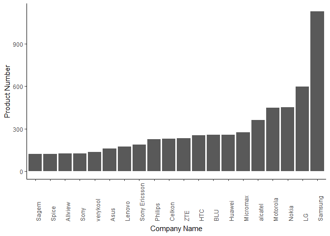

```r
library(ggplot2)
library(dplyr)
library(readr)
mobile = read.csv("E:\\TahlilDade\\mobile_data.csv")
mobile %>% group_by(company) %>% summarise(num = sum(!is.na(device))) %>% arrange(desc(num)) %>% slice(1:20) -> comp
p = ggplot(comp, aes(x = reorder(company, num), y = num))
print(p + geom_col() + theme_classic() + theme(axis.text.x = element_text(angle = 90, hjust = 0)) + xlab("Company Name") + ylab("Product Number"))
```

***

۲. نمودار زمانی طول عرض ضخامت و کیفیت دوربین گوشی ها را بکشید و به نمودار هر یک مدل خطی اضافه کنید.

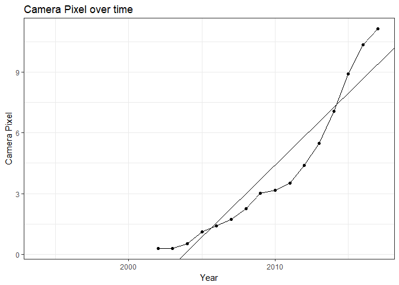

```r
library(ggplot2)
library(readr)
library(ggthemes)
mobile = read.csv("E:\\TahlilDade\\mobile_data.csv")
mobile %>% group_by(year) %>% summarise(m_cam_px = mean(cam_px, na.rm = TRUE), m_dim_length = mean(dim_length, na.rm = TRUE), m_dim_breadth = mean(dim_breadth, na.rm = TRUE), m_dim_thickness = mean(dim_thickness, na.rm = TRUE))->stat
p = ggplot(data = stat, aes(x = year, y = m_cam_px))
coef = coef(lm(m_cam_px ~ year, data = stat))
print(p + geom_point() + geom_abline(intercept = coef[1], slope = coef[2]) + geom_line() + ggtitle("Camera Pixel over time") + xlab("Year") + ylab("Camera Pixel") + theme_bw())
```

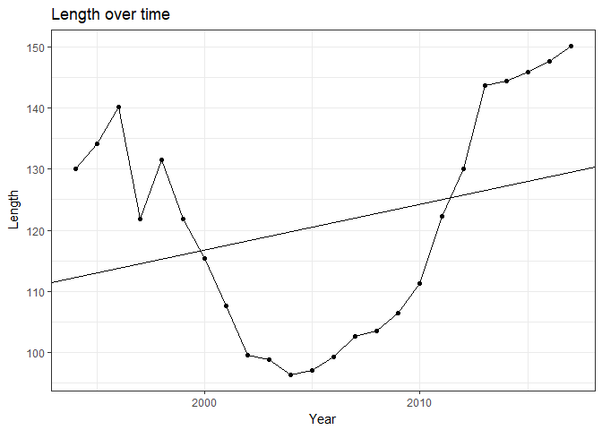

```r
p = ggplot(data = stat, aes(x = year, y = m_dim_length))
coef = coef(lm(m_dim_length ~ year, data = stat))
print(p + geom_point() + geom_abline(intercept = coef[1], slope = coef[2]) + geom_line() + ggtitle("Length over time") + xlab("Year") + ylab("Length") + theme_bw())
```

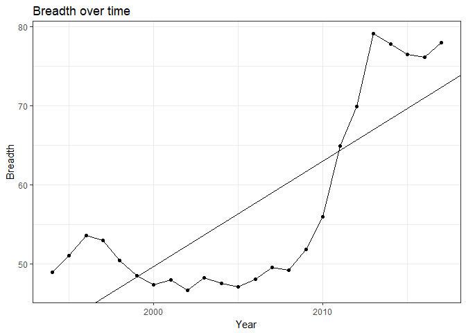

```r
p = ggplot(data = stat, aes(x = year, y = m_dim_breadth))
coef = coef(lm(m_dim_breadth ~ year, data = stat))
print(p + geom_point() + geom_abline(intercept = coef[1], slope = coef[2]) + geom_line() + ggtitle("Breadth over time") + xlab("Year") + ylab("Breadth") + theme_bw())
```

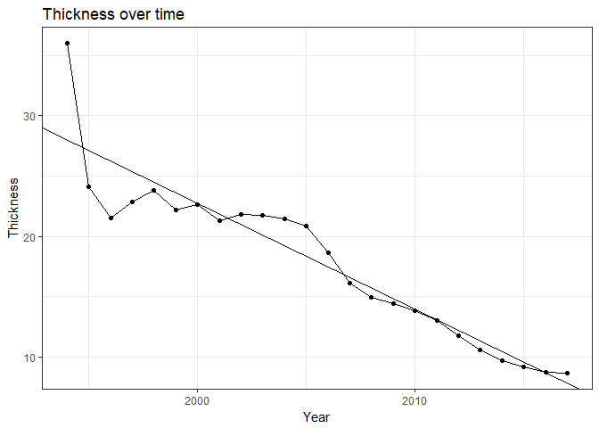

```r
p = ggplot(data = stat, aes(x = year, y = m_dim_thickness))
coef = coef(lm(m_dim_thickness ~ year, data = stat))
print(p + geom_point() + geom_abline(intercept = coef[1], slope = coef[2]) + geom_line() + ggtitle("Thickness over time") + xlab("Year") + ylab("Thickness") + theme_bw())
```

۳. نمودار ستونی متوسط قیمت گوشی بر حسب تعداد سیم کارت و دسترسی به LTE را رسم نمایید.

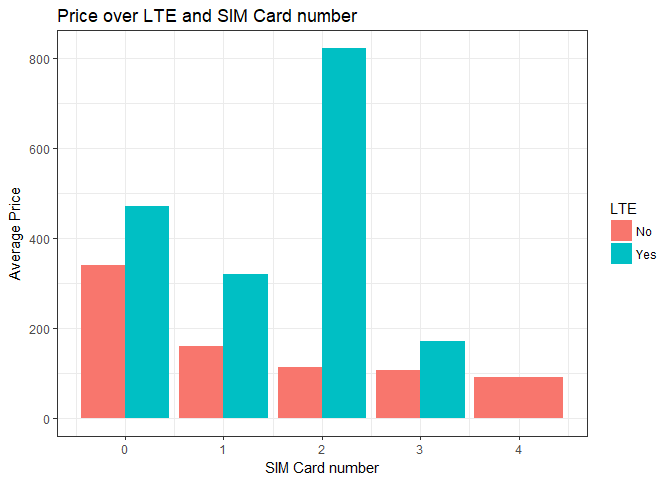

```r
library(ggplot2)
library(readr)
library(dplyr)
library(ggthemes)
mobile = read.csv("E:\\TahlilDade\\mobile_data.csv")
mobile %>% group_by(LTE, sim_no) %>% summarise(m = mean(price, na.rm = TRUE)) -> stat
p = ggplot(data = stat, aes(x = sim_no, y = m, fill = LTE))
print(p + geom_col(position = 'dodge') + theme_bw() + xlab("SIM Card number") + ggtitle("Price over LTE and SIM Card number") + ylab("Average Price"))
```

۴. نمودار جعبه ایی ضحامت گوشی هایی که در سال ۲۰۱۷ معرفی شده اند را برحسب اینکه کمیت جک هدفون رسم نمایید

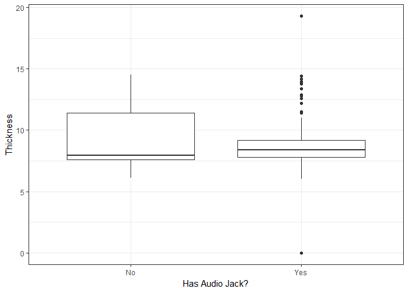

```r
library(ggplot2)
library(readr)
library(ggthemes)
mobile = read.csv("E:\\TahlilDade\\mobile_data.csv")
p = ggplot(data = mobile[which(mobile$year == 2017), ], aes(x = audio_jack, y = dim_thickness))
print(p + geom_boxplot() + theme_bw() + xlab("Has Audio Jack?") + ylab("Thickness"))
```

۵. مفهوم ppi را در گوشی های موبایل محاسبه و هیستوگرام آن را رسم نمایید. همچنین نمودار سالانه متوسط این کمیت را بکشید. کدام گوشی بیشترین ppi را دارد؟

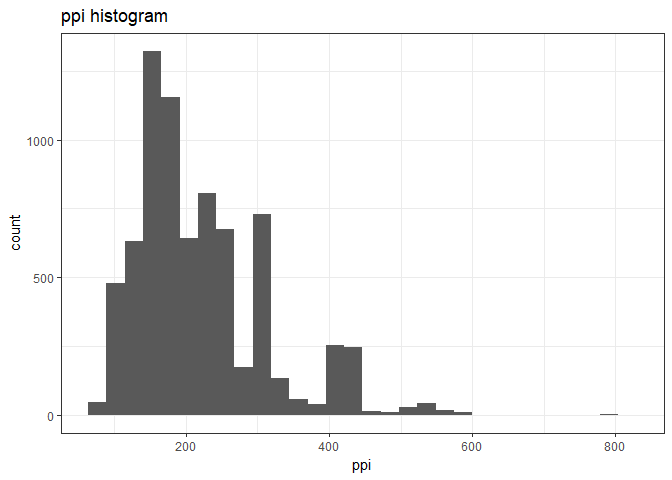

```r
library(ggplot2)
library(readr)
library(dplyr)
library(ggthemes)
mobile = read.csv("E:\\TahlilDade\\mobile_data.csv")
mobile %>% mutate(ppi = (mobile$px_row**2 + mobile$px_col**2)**0.5 / mobile$display_size) ->mobile_ppi
p = ggplot(data = mobile_ppi, aes(x = ppi))
print(p + geom_histogram() + theme_bw() + ggtitle("ppi histogram"))
```

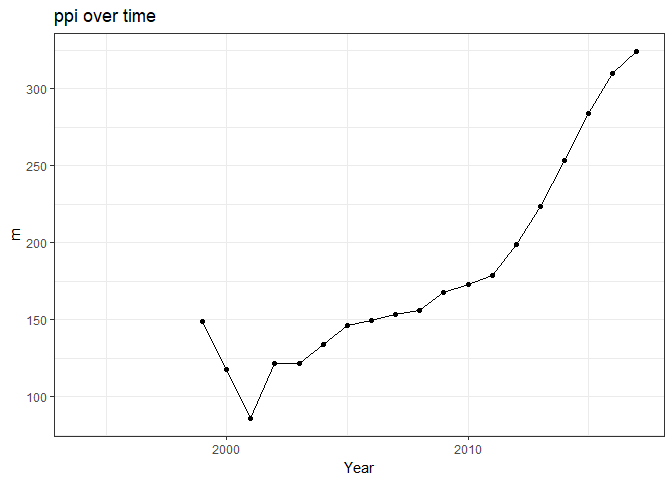

```r
mobile_ppi %>% group_by(year) %>% summarise(m = mean(ppi, na.rm = TRUE)) ->stat
p = ggplot(data = stat, aes(x = year, y = m))
print(p + geom_point() + geom_line() + ggtitle("ppi over time") + xlab("Year") + theme_bw())
```

```r
print("Max ppi:")
```

```
## [1] "Max ppi:"
```

```r
print(mobile_ppi[which(mobile_ppi$ppi == max(mobile_ppi$ppi, na.rm = TRUE)), ])
```

```
##      company            device price year      announced dim_length
## 7426    Sony Xperia XZ Premium   660 2017 2017, February        156
##      dim_breadth dim_thickness weight
## 7426          77           7.9    195
##                                    display_tech display_size px_row px_col
## 7426 IPS LCD capacitive touchscreen, 16M colors         5.46   3840   2160
##      aspect_row aspect_col
## 7426         16          9
##                                                                                                               camera
## 7426 19 MP (f/2.0, 25mm, 1/2.3"), gyro EIS, predictive phase detection and laser autofocus, LED flash, check quality
##                                             video cam_px
## 7426 2160p@30fps, 720p@960fps, HDR, check quality     19
##                                            selfie sel_px sim_no
## 7426 13 MP (f/2.0, 22mm, 1/3", 1.12 Ã‚Âµm), 1080p     13      2
##                                                          os  os_type
## 7426 Android 7.1 (Nougat), upgradable to Android 8.0 (Oreo) Android
##      card_slot                         chipset
## 7426   microSD Qualcomm MSM8998 Snapdragon 835
##                                               cpu        gpu ram LTE gps
## 7426 Octa-core (4x2.45 GHz Kryo & 4x1.9 GHz Kryo) Adreno 540   4 Yes Yes
##      radio nfc wlan audio_jack battery_mah bt_v      ppi
## 7426    No Yes  Yes        Yes        3230    5 806.9257
```

۶. در گذشته به بعضی از مدل های گوشی نوکیا **گوشکوب** گفته می شد. سعی کنید برای این مفهوم کمیتی مناسب تعریف کنید . ده گوشکوب برتر را پیدا کرده و نمودار گوشکوبیت آن را رسم نمایید.

در گذشته علت این نام گزاری این بود که گوشی های نوکیا بسیار محکم وبه اصطلاح جان سخت بودند. با این وجود در داده های ما هیچ داده ای وجود ندارد که با آن بتوان چچنین معیاری را حساب کرد پس به ناچار به شباهت ظاهری پناه بردیم و نسبت مشخصی را تعیین کردیم تا هرچه نسبت ضخامت و عرض بر روی طول به آن نزدیک تر بود آنرا بیشتر شبیه گوشکوب بیابیمو سپس گوشی های یافت شده را اسکیل کردیم.نسبت مضخص را با امتحان و خطا بدست آوردیم.

```r
library(ggplot2)
library(readr)
library(dplyr)
library(ggthemes)
mobile = read.csv("E:\\TahlilDade\\mobile_data.csv")
ideal <- 0.31
mobile %>% mutate(x =  ((dim_breadth * dim_thickness)**0.5 / dim_length)) %>%  arrange(desc(x)) %>% filter(x < ideal) %>% mutate(gooshkoobiat = x - 0.309) %>% slice(1:10) -> gooshkoob

print(gooshkoob)
```

```
## # A tibble: 10 x 38
##    company     device      price  year announced    dim_length dim_breadth
##    <fct>       <fct>       <int> <int> <fct>             <dbl>       <dbl>
##  1 Philips     W727           NA  2012 2012, Janua~      110          56.5
##  2 Ericsson    T29s           NA  2001 2001, Febru~      101          49.0
##  3 Nokia       6110 Navig~   230  2007 2007, Febru~      101          49.0
##  4 Nokia       5210           NA  2002 2002, Q1          106          47.5
##  5 Nokia       6500           NA  2002 2002, Q1           97.0        43.0
##  6 Nokia       6680          230  2005 2005, Q1          109          55.2
##  7 Philips     Fisio 121      NA  2002 2002              106          49.0
##  8 Philips     Fisio 120      NA  2002 2002              106          49.0
##  9 Sony Erics~ T200           NA  2002 2002, Oct         105          48.0
## 10 Motorola    C118           40  2005 2005, Q3          101          45.7
## # ... with 31 more variables: dim_thickness <dbl>, weight <dbl>,
## #   display_tech <fct>, display_size <dbl>, px_row <int>, px_col <int>,
## #   aspect_row <int>, aspect_col <int>, camera <fct>, video <fct>,
## #   cam_px <dbl>, selfie <fct>, sel_px <dbl>, sim_no <int>, os <fct>,
## #   os_type <fct>, card_slot <fct>, chipset <fct>, cpu <fct>, gpu <fct>,
## #   ram <dbl>, LTE <fct>, gps <fct>, radio <fct>, nfc <fct>, wlan <fct>,
## #   audio_jack <fct>, battery_mah <int>, bt_v <dbl>, x <dbl>,
## #   gooshkoobiat <dbl>
```

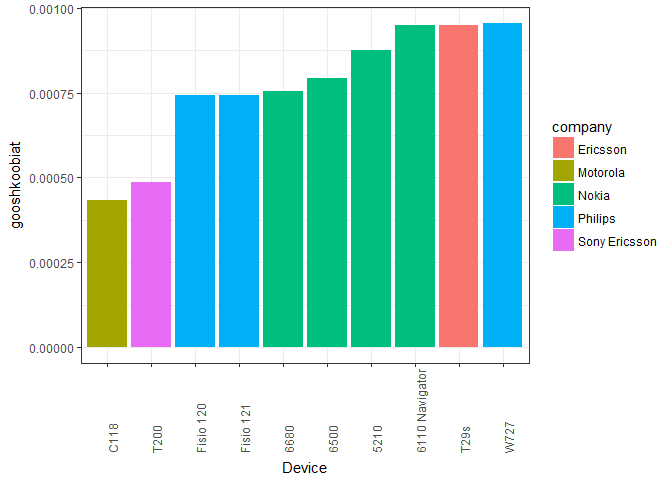

```r
p = ggplot(data = gooshkoob, aes(x = reorder(device, gooshkoobiat), y = gooshkoobiat))
print(p + geom_col(aes(fill = company)) + xlab("Device")+ theme_bw() + theme(axis.text.x = element_text(angle = 90, hjust = 0)))
```

۷. آیا تلفن همراهی وجود دارد که در آب غرق نشود؟ اگر جواب بله هست تمام گوشی های که این خاصیت را دارند بیابید. با کشیدن یک نمودار به این سوال پاسخ دهید.

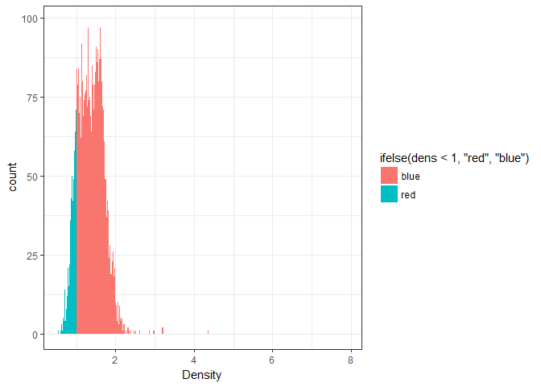

```r
library(ggplot2)
library(readr)
library(dplyr)
library(ggthemes)
mobile = read.csv("E:\\TahlilDade\\mobile_data.csv")
mobile %>% mutate(dens = 1000 * weight / (dim_length * dim_breadth * dim_thickness)) ->stat
p = ggplot(data = stat, aes(dens, fill = ifelse(dens < 1, "red","blue")))
print(p + geom_histogram(binwidth = 0.01) + theme_bw() + xlab("Density"))
```

```r
print("All this phones:")
```

```
## [1] "All this phones:"
```

```r
stat %>% filter(dens < 1) %>% print()
```

[output not shown]

[output cut: 12165 more lines]

۸. نمودار پراکنش حجم ذخیره سازی باطری و وزن را رسم نمایید. میزان همبستگی بین این دو کمیت را محاسبه کنید.

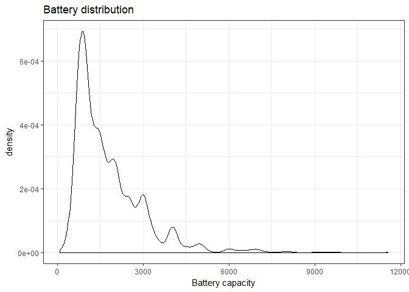

```r
library(ggplot2)
library(readr)
library(dplyr)
library(ggthemes)
mobile = read.csv("E:\\TahlilDade\\mobile_data.csv")
p = ggplot(data = mobile, aes(x = battery_mah))
print(p + geom_density() + theme_bw() + ggtitle("Battery distribution") + xlab("Battery capacity"))
```

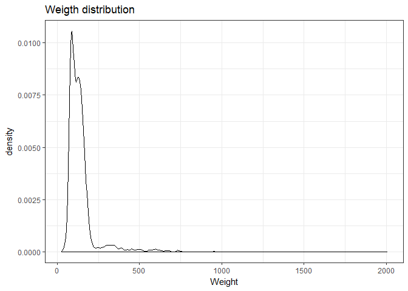

```r
p = ggplot(data = mobile, aes(x = weight))
print(p + geom_density() + theme_bw() + ggtitle("Weigth distribution") + xlab("Weight"))
```

```r
mobile = mobile[which(is.na(mobile$battery_mah) == FALSE & is.na(mobile$weight) == FALSE), ]
weight = mobile$weight
battery = mobile$battery_mah
print("Correlation is:")
```

```
## [1] "Correlation is:"
```

```r
print(cor(weight, battery))
```

```
## [1] 0.8086273
```

۹. قیمت پرچمداران یک برند خاص مثلا سامسونگ را بیابید و نمودار قیمت زمان و نام مدل را رسم نمایید.

برا تشخیص پرچمداران به دو صورت عمل شد.یکی در ابتدا همه خصوصیات من جمله کیفیت دوربین و فیمت و کیفیت صفحه نمایش نرمال شدند (بر ماکسیمم همان سال و همان برند تقسیم شدند) و سپس با هم جمع شده و بالاترین امتیاز به عنوان پرچمدار انتخاب شد در این معیار با اینکه گوشی های بسیار خوبی به عنوان پرچمدار انتخاب شدند ولی این انتخاب با انتخاب سایت ها متفاوت بود فلذا صرفا قیمت های داده پرتشان را حذف کردیم و بالاترین قیمت را به عنوان پرچمدار اعلام کردیم.

```r
library(ggplot2)
library(readr)
library(dplyr)
library(ggthemes)
mobile = read.csv("E:\\TahlilDade\\mobile_data.csv")
mobile %>% mutate(ppi = (mobile$px_row**2 + mobile$px_col**2)**0.5 / mobile$display_size) ->mobile_ppi
mobile_ppi %>% filter(company == "Samsung") -> sam
sam %>% group_by(year) %>% mutate(n_price = price/max(price, na.rm = TRUE), n_cam_px = cam_px/max(cam_px, na.rm = TRUE), n_sel_px = sel_px/max(sel_px, na.rm = TRUE), n_ram = ram/max(ram, na.rm = TRUE), n_ppi = ppi/max(ppi, na.rm = TRUE), n_battery_mah = battery_mah/max(battery_mah, na.rm = TRUE), score = n_price + n_cam_px + n_sel_px + n_ram + (LTE == "Yes") + (gps == "Yes") + (wlan == "Yes") + (nfc == "Yes") + n_ppi + n_battery_mah) ->flagship
#this is first approach which won't be use in future
sam %>% group_by(year) %>% filter(price < 2000) %>% mutate(score = price) ->flagship
#this is second approach
flagship %>% arrange(desc(score)) %>% slice(1) -> flagship
flagship %>% print()
```

```
## # A tibble: 15 x 38
## # Groups:   year [15]
##    company device      price  year announced        dim_length dim_breadth
##    <fct>   <fct>       <int> <int> <fct>                 <dbl>       <dbl>
##  1 Samsung E630           80  2004 2004, Q4               85.0        43.0
##  2 Samsung D820          110  2005 2005, Q4               95.0        51.0
##  3 Samsung P930          290  2006 2006, December        107          49.0
##  4 Samsung Serenata     1000  2007 2007, October. ~      110          63.0
##  5 Samsung S9402 Ego     690  2008 2008, December.~      115          48.0
##  6 Samsung B7620 Gior~   280  2009 2009, October. ~      118          58.3
##  7 Samsung I6500U Gal~   310  2010 2010, March. Re~      117          59.0
##  8 Samsung P7500 Gala~   370  2011 2011, March. Re~      257         175
##  9 Samsung Ativ Tab P~   440  2012 2012, October         266         168
## 10 Samsung Galaxy Rou~   680  2013 2013, October         151          79.6
## 11 Samsung Galaxy Not~   670  2014 2014, January         296         204
## 12 Samsung Galaxy View   640  2015 2015, October         452         276
## 13 Samsung Galaxy Not~   850  2016 2016, August. R~      154          73.9
## 14 Samsung Galaxy Not~  1000  2017 2017, August          162          74.8
## 15 Samsung Galaxy On5~   220    NA Not announced y~      143          69.6
## # ... with 31 more variables: dim_thickness <dbl>, weight <dbl>,
## #   display_tech <fct>, display_size <dbl>, px_row <int>, px_col <int>,
## #   aspect_row <int>, aspect_col <int>, camera <fct>, video <fct>,
## #   cam_px <dbl>, selfie <fct>, sel_px <dbl>, sim_no <int>, os <fct>,
## #   os_type <fct>, card_slot <fct>, chipset <fct>, cpu <fct>, gpu <fct>,
## #   ram <dbl>, LTE <fct>, gps <fct>, radio <fct>, nfc <fct>, wlan <fct>,
## #   audio_jack <fct>, battery_mah <int>, bt_v <dbl>, ppi <dbl>,
## #   score <int>
```

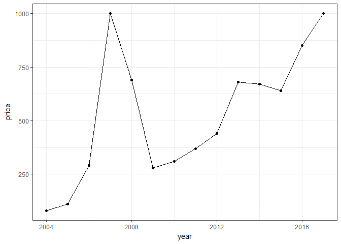

```r
p = ggplot(data = flagship, aes(x = year, y = price))
print(p + geom_point() + geom_line() + theme_bw())
```

۱۰. سه نمودار جالب رسم کنید و توضیح دهید چرا از نظر شما جالب است؟

نمودار اول: در این نمودار می خواهیم ببینیم کدام یک از کمپانی ها بیشتر نسبت طلایی را در گوشیشان رعایت می کنند.

```r
library(ggplot2)
library(readr)
library(dplyr)
library(ggthemes)
mobile = read.csv("E:\\TahlilDade\\mobile_data.csv")
mobile %>% mutate(x =  aspect_row/ aspect_col)%>% group_by(company) %>% summarise(m = mean(x < 1.65 & x > 1.55 , na.rm = TRUE)) %>% arrange(desc(m)) %>% slice(1:20) ->company_n
company_n
```

```
## # A tibble: 20 x 2
##    company        m
##    <fct>      <dbl>
##  1 Benefon   1.00
##  2 Nvidia    1.00
##  3 Amazon    0.765
##  4 Toshiba   0.310
##  5 Dell      0.300
##  6 Asus      0.252
##  7 Lenovo    0.191
##  8 HP        0.184
##  9 Acer      0.184
## 10 Vodafone  0.113
## 11 Prestigio 0.107
## 12 Haier     0.100
## 13 Sony      0.0948
## 14 BQ        0.0833
## 15 Huawei    0.0816
## 16 Samsung   0.0779
## 17 Allview   0.0574
## 18 Orange    0.0556
## 19 Plum      0.0395
## 20 alcatel   0.0392
```

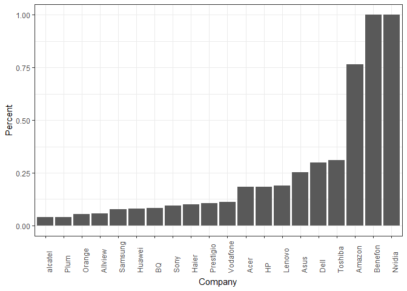

```r
p = ggplot(data = company_n, aes(x = reorder(company, m), y = m))
print(p + geom_col() + theme_bw() + theme(axis.text.x = element_text(angle = 90, hjust = 0)) + ylab("Percent") + xlab("Company"))
```

نمودار دوم: در این نمودار می خواهیم ببینیم آیا اوجگیری دوربین های سلفی پس از اوج گیری اینستاگرام بود (در واقع علت آن بود) یا قبل از آن بود.

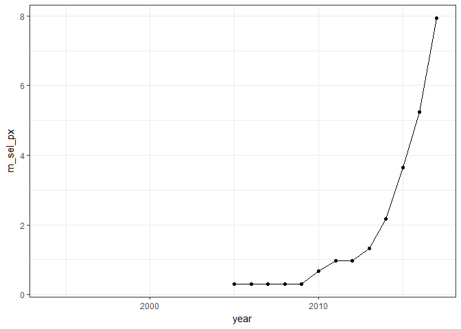

```r
library(ggplot2)
library(readr)
library(dplyr)
library(ggthemes)
mobile = read.csv("E:\\TahlilDade\\mobile_data.csv")
mobile %>% group_by(year) %>% summarise(m_sel_px = mean(sel_px, na.rm = TRUE)) -> selfie
p = ggplot(data = selfie, aes(x = year, y = m_sel_px))
print(p + geom_point() + theme_bw() + geom_line())
```

که همانطور که مشاهده کردید این اوجگیری حدود ۱ سال پس از اوجگیری اینستاگرام بوده پس احتمالا گرایش مردم به اینستاگرام سبب رواج سلفی شده است.

نمودار سوم: در این نمودار می خواهیم ببینیم بین کمپانی های مشهور و تکنولوژی های صفحه مشهور هر کمپانی به کدام یک گرایش بیشتری دارد.

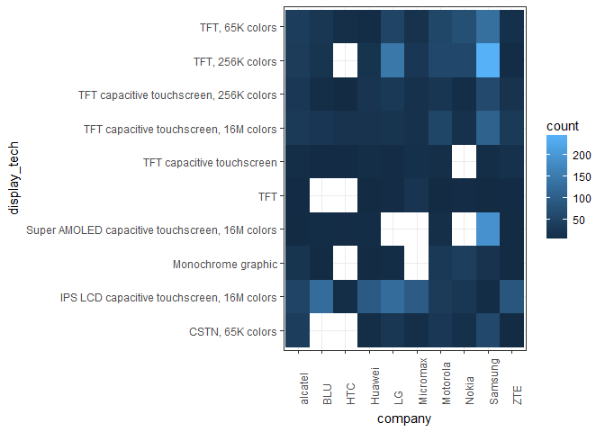

```r
library(ggplot2)
library(readr)
library(dplyr)
library(ggthemes)
mobile = read.csv("E:\\TahlilDade\\mobile_data.csv")
mobile %>% group_by(company) %>% summarise(num = n()) %>% arrange(desc(num)) %>% slice(1:10) ->fam_company
mobile %>% group_by(display_tech) %>% summarise(num = n()) %>% arrange(desc(num)) %>% slice(1:10) ->fam_dis
mobile %>% filter(is.na(company) == FALSE & is.na(display_tech) == FALSE & is.element(company, fam_company$company) & is.element(display_tech, fam_dis$display_tech)) %>% group_by(company, display_tech) %>% summarise(count = n()) -> stat
print(ggplot(data = stat, aes(x = company, y = display_tech, fill = count)) + geom_tile() + theme_bw() + theme(axis.text.x = element_text(angle = 90, hjust = 0)))
```